# Retail Demand Forecasting & Inventory Optimization

## Day 10

### Phase-10 :- Model Comparison and Best_Model_Selection

```python
# Import Required Libraries

import pandas as pd
import numpy as np
import matplotlib.pyplot as plt
import seaborn as sns

plt.style.use("ggplot")

print("Libraries Imported Successfully")
```

```
Libraries Imported Successfully
```

```python
# Load Prediction Files

prophet_df = pd.read_csv(
    r"C:\Users\LENOVO\Desktop\Zalima Development Project 2\Retail Demand Forecasting & Inventory optimization\data\processed\foods_1_forecast_results.csv"
)

lightgbm_df = pd.read_csv(
    r"C:\Users\LENOVO\Desktop\Zalima Development Project 2\Retail Demand Forecasting & Inventory optimization\data\processed\foods_1_lightgbm_predictions.csv"
)

arima_df = pd.read_csv(
    r"C:\Users\LENOVO\Desktop\Zalima Development Project 2\Retail Demand Forecasting & Inventory optimization\data\processed\foods_1_arima_predictions.csv"
)

print("All Files Loaded Successfully")
```

```
All Files Loaded Successfully
```

```python
print(prophet_df.shape)
print(lightgbm_df.shape)
print(arima_df.shape)
```

```
(30, 4)
(30, 4)
(30, 4)
```

```python
prophet_df.head()
```

|  | Date | Actual_Sales | Predicted_Sales | Error |
| --- | --- | --- | --- | --- |
| 0 | 2016-03-26 | 5285 | 3884.679692 | 1400.320308 |
| 1 | 2016-03-27 | 3956 | 3561.319379 | 394.680621 |
| 2 | 2016-03-28 | 2261 | 3067.473775 | -806.473775 |
| 3 | 2016-03-29 | 2262 | 3085.702941 | -823.702941 |
| 4 | 2016-03-30 | 2282 | 3143.164527 | -861.164527 |

```python
# Check Columns

print(prophet_df.columns.tolist())
print(lightgbm_df.columns.tolist())
print(arima_df.columns.tolist())
```

```
['Date', 'Actual_Sales', 'Predicted_Sales', 'Error']
['Date', 'Actual_Sales', 'Predicted_Sales', 'Error']
['Date', 'Actual_Sales', 'Predicted_Sales', 'Error']
```

```python
# =====================================================
# Final Model Performance Comparison
# =====================================================

comparison_df = pd.DataFrame({

    "Model": ["LightGBM", "Prophet", "ARIMA"],

    "Accuracy (%)": [
        92.59,
        87.05,
        69.89
    ],

    "MAPE (%)": [
        7.41,
        12.95,
        30.11
    ],

    "RMSE": [
        328.54,
        472.83,
        888.76
    ],

    "MAE": [
        234.92,
        368.30,
        845.89
    ]
})

comparison_df
```

|  | Model | Accuracy (%) | MAPE (%) | RMSE | MAE |
| --- | --- | --- | --- | --- | --- |
| 0 | LightGBM | 92.59 | 7.41 | 328.54 | 234.92 |
| 1 | Prophet | 87.05 | 12.95 | 472.83 | 368.30 |
| 2 | ARIMA | 69.89 | 30.11 | 888.76 | 845.89 |

```python
# =====================================================
# Rank Models Based On Accuracy
# =====================================================

comparison_ranked = comparison_df.sort_values(
    by="Accuracy (%)",
    ascending=False
)

comparison_ranked
```

|  | Model | Accuracy (%) | MAPE (%) | RMSE | MAE |
| --- | --- | --- | --- | --- | --- |
| 0 | LightGBM | 92.59 | 7.41 | 328.54 | 234.92 |
| 1 | Prophet | 87.05 | 12.95 | 472.83 | 368.30 |
| 2 | ARIMA | 69.89 | 30.11 | 888.76 | 845.89 |

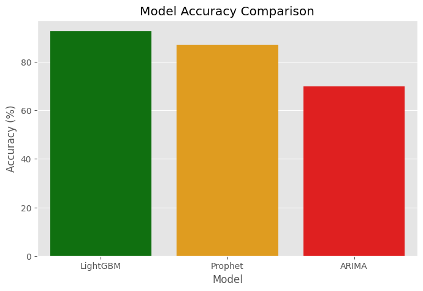

```python
# =====================================================
# Accuracy Comparison Chart
# =====================================================

plt.figure(figsize=(8,5))

sns.barplot(
    data=comparison_df,
    x="Model",
    y="Accuracy (%)",
    hue="Model",
    palette=["green", "orange", "red"],
    legend=False
)

plt.title("Model Accuracy Comparison")
plt.ylabel("Accuracy (%)")

plt.show()
```

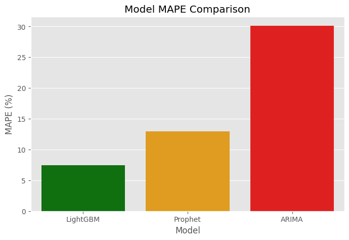

```python
# =====================================================
# MAPE Comparison
# =====================================================

plt.figure(figsize=(8,5))

sns.barplot(
    data=comparison_df,
    x="Model",
    y="MAPE (%)",
    hue="Model",
    palette=["green", "orange", "red"],
    legend=False
)

plt.title("Model MAPE Comparison")
plt.ylabel("MAPE (%)")

plt.show()
```

```python
# =====================================================
# Best Model Selection
# =====================================================

best_model = comparison_df.loc[
    comparison_df["Accuracy (%)"].idxmax(),
    "Model"
]

best_accuracy = comparison_df["Accuracy (%)"].max()

print("Best Model :", best_model)
print("Accuracy :", best_accuracy, "%")
```

```
Best Model : LightGBM
Accuracy : 92.59 %
```

```python
# =====================================================
# Final Business Recommendation
# =====================================================

print("""
FINAL BUSINESS RECOMMENDATION

1. LightGBM delivered the highest forecasting accuracy.
2. LightGBM achieved the lowest forecasting error.
3. Prophet performed reasonably well but was less accurate.
4. ARIMA produced the weakest forecasting performance.
5. LightGBM is recommended for production deployment.

Selected Model : LightGBM
""")
```

```
FINAL BUSINESS RECOMMENDATION

1. LightGBM delivered the highest forecasting accuracy.
2. LightGBM achieved the lowest forecasting error.
3. Prophet performed reasonably well but was less accurate.
4. ARIMA produced the weakest forecasting performance.
5. LightGBM is recommended for production deployment.

Selected Model : LightGBM
```

```python
# =====================================================
# Final Project Conclusion Table
# =====================================================

comparison_df.sort_values(
    by="Accuracy (%)",
    ascending=False
)
```

|  | Model | Accuracy (%) | MAPE (%) | RMSE | MAE |
| --- | --- | --- | --- | --- | --- |
| 0 | LightGBM | 92.59 | 7.41 | 328.54 | 234.92 |
| 1 | Prophet | 87.05 | 12.95 | 472.83 | 368.30 |
| 2 | ARIMA | 69.89 | 30.11 | 888.76 | 845.89 |

# Model Comparison & Best Model Selection - FOODS_1 Department

## Objective

The objective of this notebook was to compare the forecasting performance of Prophet, LightGBM, and ARIMA models and identify the most suitable model for retail demand forecasting and inventory optimization.

## Models Evaluated

1. Prophet
2. LightGBM
3. ARIMA

## Evaluation Metrics

The models were evaluated using:

- Forecast Accuracy
- Mean Absolute Percentage Error (MAPE)
- Root Mean Squared Error (RMSE)
- Mean Absolute Error (MAE)

## Model Performance Summary

| Model | Accuracy (%) | MAPE (%) | RMSE | MAE |
| --- | --- | --- | --- | --- |
| LightGBM | 92.59 | 7.41 | 328.54 | 234.92 |
| Prophet | 87.05 | 12.95 | 472.83 | 368.30 |
| ARIMA | 69.89 | 30.11 | 888.76 | 845.89 |

## Key Findings

- LightGBM achieved the highest forecasting accuracy.
- LightGBM produced the lowest forecasting errors across all evaluation metrics.
- Prophet delivered strong forecasting performance and captured trend and seasonality effectively.
- ARIMA performed adequately but struggled during demand fluctuations and seasonal variations.

## Business Impact

Accurate demand forecasting helps:

- Reduce stockout situations.
- Minimize excess inventory costs.
- Improve replenishment planning.
- Support data-driven inventory decisions.
- Enhance overall supply chain efficiency.

## Final Model Selection

**Selected Model: LightGBM**

### Reasons for Selection

- Highest Forecast Accuracy (92.59%)
- Lowest MAPE (7.41%)
- Lowest RMSE (328.54)
- Lowest MAE (234.92)

## Conclusion

Based on comprehensive model evaluation, LightGBM was identified as the best-performing forecasting model for the FOODS_1 department. The model demonstrated superior predictive accuracy and lower forecasting errors compared to Prophet and ARIMA. Therefore, LightGBM is recommended as the final forecasting model for demand forecasting and inventory optimization in this project.